# Número Efectivo de Reproducción $R_t$ del COVID-19 en Bolivia

B. Bellot - Julio 11, 2020

### Resumen:

> El número básico de reproducción, $R_0$, es un parámetro ampliamente usado en modelos epidemiológicos. La naturaleza no lineal de la dispersión de un virus en una población humana limita el valor predictivo de $R_0$ a un periodo breve al inicio de una pandemia. Al actualizar el valor de $R_0$ a un valor efectivo ($R_t$) basado en la evolución del número de casos se hace posible conservar la vigencia de los modelos epidemiológicos hasta una etapa más avanzada en la pandemia. Se ha utilizado el modelo de [Bettencourt y Ribeiro](https://doi.org/10.1371/journal.pone.0002185), que consiste en un esquema bayesiano que estima la distribución de probabilidad de $R_t$, adaptando el [código de Kevin Systrom](http://systrom.com/blog/the-metric-we-need-to-manage-covid-19/) a los datos reportados en el [sitio oficial del Gobierno de Bolivia sobre el COVID-19](https://www.boliviasegura.gob.bo/estadisticas.php). Obteniendo así una estimación de $R_t$ para cada Departamento y para Bolivia en su conjunto, además de su evolución a lo largo de las últimas semanas. También se discute sobre la aplicabilidad de proyecciones basadas en este modelo.

> **Keywords:** Número básico de reproducción, modelos teóricos, brotes pandémicos, transmisión de enfermedades infecciosas, R0, modelado matemático, estadística bayesiana, tiempo de duplicación

## Introducción

El Número Básico de Reproducción $R_0$, es una métrica epidemiológica usada para describir la transmisibilidad de agentes infecciosos [10]. Se define como el número de nuevos casos que un caso genera en promedio en el transcurso de su periodo infeccioso[11].

El valor de $R_0$ depende de numerosos factores biológicos, sociales y ambientales que gobiernan la transmisión de patógenos [10]. Su importancia radica en que es un estimador del potencial epidemológico de una enfermedad. El crecimiento inicial de una enfermedad depende fuertemente del valor que adopte $R_0$ en esa determinada población, si $R_0$ es mucho menor a 1 el número de casos decrecerá rápidamente, todo lo opuesto si $R_0$ es mucho mayor a 1. Cuando $R_0$ es igual a 1 el número de casos activos se mantendrá constante en el tiempo [2]. $R_0$ es rara vez medido directamente, y los valores que adopta son dependientes de las suposiciones y estructura de los modelos [10].

Liu et al [4] }recopila los resultados de 12 estudios sobre el COVID19 que reportan valores entre 1.5 y 6.68, la Organización Mundial de la Salud inicialmente reportaba un valor de 2.7. Posteriores estudios reportan valores cercanos a 6. Como referencia adicional se presentan valores de $R_0$ para varias enfermedades.

| Enfermedad | Via de transmisión | Valores de $R_0$ reportados |
| --- | --- | --- |
| Sarampión | Aerosol | 12 – 18 |
| Varicela | Aerosol | 10 – 12 |
| Viruela | Gotitas respiratorias | 3.5 – 6 |
| HIV/AIDS | Fluídos corporales | 2 – 5 |
| SARS | Gotitas respiratorias | 0.19 – 1.08 |
| **COVID-19** | Gotitas respiratorias | [4] **1.5 - 6.68** OMS: **2.7** |
| Resfrío común | Gotitas respiratorias | 2 – 3 |
| Difteria | Saliva | 1.7 – 4.3 |
| Ebola | Fluídos corporales | 1.5 – 1.9 |
| MERS | Gotitas respiratorias | 0.3 – 0.8 |

En la práctica, los datos epidemiológicos típicamente permiten solo una estimación del número *efectivo* de reproducción $R_t$ [1], que puede diferir de $R_0$ debido a inmunidad adquirida y otros factores. Para una enfermedad infecciosa emergente, cuando la transmisión es incipiente y el patógeno esta en proceso de adaptarse a la población, se vuelve crucial el monitoreo cuantitativo de la variación temporal del número de reproduccion efectiva. De esta manera, el seguimiento a una enfermedad emergente se puede formalizar en términos del monitoreo de $R_t$ [1].

#### Relaciónes con el modelo SIR y la Tasa de Duplicación

El modelo **SIR** (Suceptible-Infectado-Removido) es uno de los modelos más fundamentales de la epidemiología, su formulación matemática consiste de un sistema de ecuaciones diferenciales ordinarias

$ \frac{dS}{dt} = - \beta \frac{S}{N} I $

$ \frac{dI}{dt} = \beta \frac{S}{N} I - \gamma I $

$ \frac{dR}{dt} = \gamma I $

Donde $N$ representa el número de habitantes de la población, $S$ representa el número de individuos suceptibles a la enfermedad, $I$ representa el número de infectados $R$ representa el número de individuos removidos o inmunizados a la enfermedad, ya sea por recuperación o fallecimiento, $\beta$ representa la tasa de transmisión de la enfermedad y $\gamma$ representa la tasa de recuperación (siendo $1/\gamma$ el periodo medio de recuperación).

En términos de los parámetros de este modelo el número efectivo de reproducción $R_t$ esta definido por la siguiente ecuación:

$$R_t = \frac{\beta}{\gamma}$$

La tasa de duplicación de casos esta íntimamente relacionada con el número de reproducción, ambos cuantifican la rapidez con la cual una enfermedad se propaga en una población. Formalmente es indistinto formular la variación del número de casos mediante el uno o la otra, la diferencia real es apenas la comodidad interpretativa que brinda cada uno, en modelos matemáticos es más sencillo trabajar con un parámetro adimensional como lo es $R_t$, en cambio, en el ámbito administrativo o médico puede ser más intuitivo referirirse a una tasa temporal. En términos matemáticos la relación entre el número de reprodución $R_t$ y la tasa de duplicación $T_d$ es la siguiente:

$$ T_d = \left(\frac{1}{\gamma}\right) \frac{ln(2)}{ln(R_t)}$$

Un factor a favor de usar $R_t$ en lugar de la tasa de duplicación es que el valor umbral entre una tendencia al crecimiento y una tendencia a decrecer es claramente el valor 1, el valor de este umbral no es evidente en el caso de tiempo de duplicación.

El propósito final de esta publicación es difundir el uso del número $R_t$ como medio de estimación del impacto de las medidas sanitarias en el desarrollo de la pandemia en Bolivia. Se ha optado por publicarlo en su presente forma de "notebook", con el código al descubierto y en el lenguaje de programación Python, para facilitar su rápida adopción por parte de los profesionales bolivianos, especialmente aquellos cuyo trabajo influye en la toma de decisiones gubernamentales.

## Materiales y Métodos

### Desarrollo del Modelo

Se instancia un modelo **SIR** para recibir datos de enfermedades infecciosas emergentes en la forma de series temporales mediante

- Invocar las variables del modelo en términos del número de los números de casos reportados
- Formular el modelo con probabilidad discreta
- Cuantificar la incertidumbre en la estimación de los parámetros epidemiológicos y reducirla, a través de asimilar nueva información.

```python
# Aqui se cargan las librerías necesarias para implementar el modelo descrito

import pandas as pd
import numpy as np

from matplotlib import pyplot as plt
from matplotlib.dates import date2num, num2date
from matplotlib import dates as mdates
from matplotlib import ticker
from matplotlib.colors import ListedColormap
from matplotlib.patches import Patch
import matplotlib.cbook as cbook

import math
import statistics as stats
import datetime

from scipy.integrate import odeint
from scipy import stats as sps
from scipy.interpolate import interp1d

from sklearn.linear_model import LinearRegression

from IPython.display import clear_output

%config InlineBackend.figure_format = 'retina'
```

#### Estimación Bayesiana

Durante los últimos meses se han reportado diariamente en Bolivia el número de nuevos casos por departamento. Los datos de casos nuevos apuntan al valor que $R_t$ puede tener a la fecha. Asumiendo que el valor de $R_t$ hoy esta relacionado su valor previo de ayer $R_{t-1}$ y para tal efecto a todos los valores, Bettencourt y Ribeiro proponen el uso de la regla de Bayes para actualizar la información disponible acerca de el verdadero valor de $R_t$ a la fecha.

Se hace uso de la siguiente forma del Teorema de Bayes:

$$ P(R_t|k)=\frac{P(k|R_t)\cdot P(R_t)}{P(k)} $$

Esta ecuación expresa que, habiendo confirmado $k$ nuevos casos, se considera que la probabilidad de $R_t$ es igual a:

- La probabilidad haber observado $k$ nuevos casos dado el valor de $R_t$, multiplicada por ...
- La probabilidad previa $P(R_t)$ ...
- Dividida entre la probabilidad de observar $k$ casos.

Para realizar las iteraciones: cada día que pasa, se utiliza la probabilidad previa de ayer $P(R_{t-1})$ para estimar la probabilidad previa de hoy $P(R_t)$. Se asume que la distribución de $R_t$ es gausiana centrada aldededor de $R_{t-1}$, de manera que $P(R_t|R_{t-1})=\mathcal{N}(R_{t-1}, \sigma)$, donde $\sigma$ es un hiperparámetro que se estimará luego. Aplicando al primer día:

$$ P(R_1|k_1) \propto P(R_1)\cdot \mathcal{L}(R_1|k_1)$$

Que se interpreta como: La probabilidad de $R_1$ dado que se observaron $k_1$ casos es proporcional a la probabilidad de observar el valor $R_1$ multiplicado por la verosimilitud de haber observado $k_1$ casos dado que $R_t$ haya adoptado el valor $R_1$. Bajo la misma lógica al segundo día se tiene:

$$ P(R_2|k_1,k_2) \propto P(R_2)\cdot \mathcal{L}(R_2|k_2) = \sum_{R_1} {P(R_1|k_1)\cdot P(R_2|R_1)\cdot\mathcal{L}(R_2|k_2) }$$

Se ha trasladado el problema a encontrar la verosimilitud.

**Seleccionando una Función de Verosimilitud $\mathcal{L}\left(k_t|R_t\right)$**

La función de verosimilitud que se necesita debe estimar cuan probable es observar $k$ casos nuevos, dado cierto valor de $R_t$.

Dada una tasa media de recurrencia de $\lambda$ nuevos casos por día, la distribución de la probabilidad de observar $k$ nuevos casos puede modelar con una distribución de Poisson:

$$P(k|\lambda) = \frac{\lambda^k e^{-\lambda}}{k!}$$

**Nota:** En caso de existir una sobredispersión del número de casos una distribución binomial negativa genera mejores resultados.

```python
# Armamos un vector columna de posibles k
k = np.arange(0, 70)[:, None]

# Se proponen diversos lambdas de prueba
lambdas = [10, 20, 30, 40]

# Evaluamos la función de masa de probabilidad para los parámetros que acabamos de instanciar usando la distribución de Poisson
y = sps.poisson.pmf(k, lambdas)

# Se muestran las dimensiones de la matriz obtenida
print(y.shape)
```

```
(70, 4)
```

La función usada permite el uso de una expresión bastante concisa, al instanciar los $k$ como un vector columna y los $\lambda$'s como una lista, evalúa la distribución sobre ambos y produce un "array" con $k$ filas y $\lambda$ columnas, lo cual es muy eficiente.

Visualicemos las funciones de probabilidad obtenidas en el paso anterior

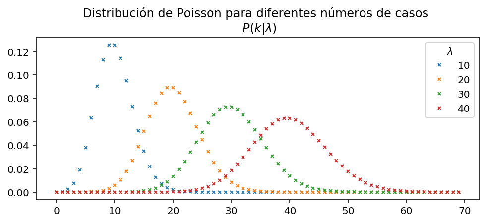

```python
fig, ax = plt.subplots(figsize=(8,3))

ax.set(title='Distribución de Poisson para diferentes números de casos \n $P(k|\lambda)$')

plt.plot(k, y, marker='x', markersize=3, lw=0)

plt.legend(title="$\lambda$", labels=lambdas);
```

La distribución de Poisson modula la variabilidad del número de nuevos casos alrededor del número de casos esperado $\lambda$. Pequeñas variaciones sobre el numero de nuevos casos esperados son más probables que grandes variaciones.

En el presente caso, se tiene la certeza de haber recibido $k$ casos nuevos y se busca determinar cual era el número de casos más probable ($\lambda$). Con ese fin, se fija el número $k$ mientras se varía $\lambda$. La función resultante es la función de verosimilitud buscada.

Por ejemplo, se observan $k=20$ casos nuevos, y se pretende saber cuan probable es cada $\lambda$:

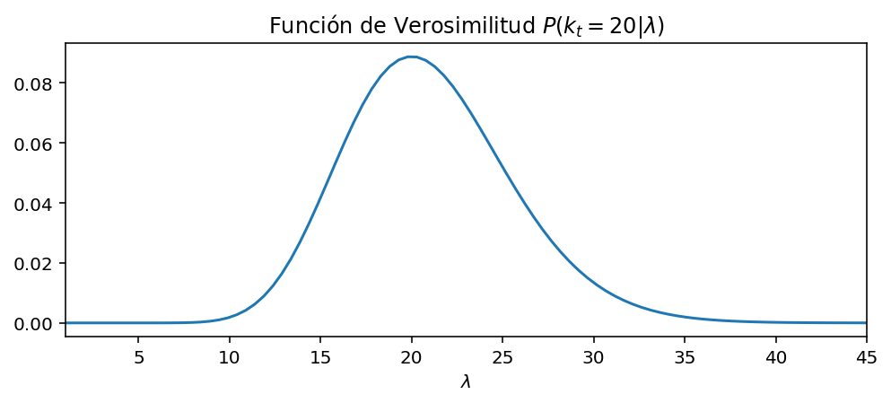

```python
k = 20

# Se generan diferentes valores de lambda

lam = np.linspace(1, 45, 90)

# Nota: el equivalente técnico de Verosimilitud en inglés es Likelihood

likelihood = pd.Series(data=sps.poisson.pmf(k, lam),
                       index=pd.Index(lam, name='$\lambda$'),
                       name='lambda')

likelihood.plot(title=r'Función de Verosimilitud $P\left(k_t=20|\lambda\right)$', figsize=(8,3));
```

Este gráfico muestra que si se registran 20 casos en un día, el valor más probable de $\lambda$ es 20, tal como se podía esperar. Pero no existe una plena certeza acerca de ese valor, otros valores de $\lambda$ tambien son posibles, con probabilidades cercanas, por ejemplo 21 o 18 y, por simple azar, se observaron 20 nuevos casos. También se puede apreciar que es poco probable que $\lambda$ sea 40 habiendo visto 20 casos.

Se tiene $P\left(\lambda_t|k_t\right)$ que esta parametrizado por $\lambda$ pero se busca $P\left(k_t|R_t\right)$ que esta parametrizado por $R_t$. Se requiere saber la relación entre $\lambda$ y $R_t$

#### Conectando $\lambda$ y $R_t$

La siguiente ecuación, derivada del trabajo de Bettencourt y Ribeiro [1] muestra una relación entre $R_t$ y $\lambda$ que se puede usar para reparametrizar la funcion de verosimilitud obtenida anteriormente.

$$ \lambda = k_{t-1}e^{\gamma(R_t-1)}$$

$$ \lambda = k_{t-1}e^{\gamma(R_t-1)}$$$$P\left(k|R_t\right) = \frac{\lambda^k e^{-\lambda}}{k!}$$

#### Evaluando la función de verosimilitud

Para una serie temporal de casos $k$. ¿Qué valores de $R_t$ se pueden estimar para cada uno de esos días?

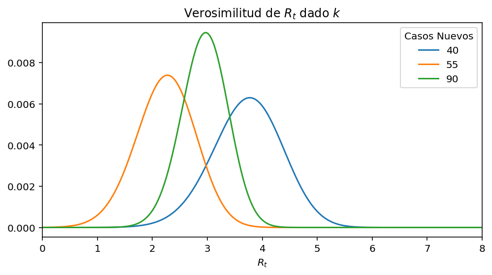

```python
k = np.array([20, 40, 55, 90])

# Se crea un "array" para cada posible valor de Rt
R_T_MAX = 12
r_t_range = np.linspace(0, R_T_MAX, R_T_MAX*100+1)

# Gamma es 1/(intervalo serial)  Este valor tambien se usa para futuros cálculos
# Se ha tomado el valor de gamma del siguiente artículo
#listado tambien en las referencias como [5]
# https://dx.doi.org/10.3201/eid2606.200357
GAMMA = 1/4

# Se construye lambda a partir de Rt a fin de usarlo en las ecuaciones siguientes
# Notese que tenemos N-1 lambdas por estar en el primer dia de la pandemia.
lam = k[:-1] * np.exp(GAMMA * (r_t_range[:, None] - 1))

# Se evalúa la verosimilitud cada dia y se normaliza la suma diaria a 1.0
likelihood_r_t = sps.poisson.pmf(k[1:], lam)
likelihood_r_t /= np.sum(likelihood_r_t, axis=0)

# Se genera el gráfico
ax = pd.DataFrame(
    data = likelihood_r_t,
    index = r_t_range
).plot(
    title='Verosimilitud de $R_t$ dado $k$',
    xlim=(0,8),
    figsize=(8,4)
)

ax.legend(labels=k[1:], title='Casos Nuevos')
ax.set_xlabel('$R_t$');
```

Se puede apreciar que cada dia se tiene una diferente estimación de $R_t$. El objetivo es combinar la información que se tiene de días previos con la del dia presente. Para eso recurrimos al Teorema de Bayes.

### Actualizando los valores con el Teorema de Bayes

Se multiplica la verosimilitud por el la probabilidad previa (que es la verosimilitud del dia anterior) para obtener la probabilida posterior. Esto se realiza usando el producto cumulativo de cada día consecutivo:

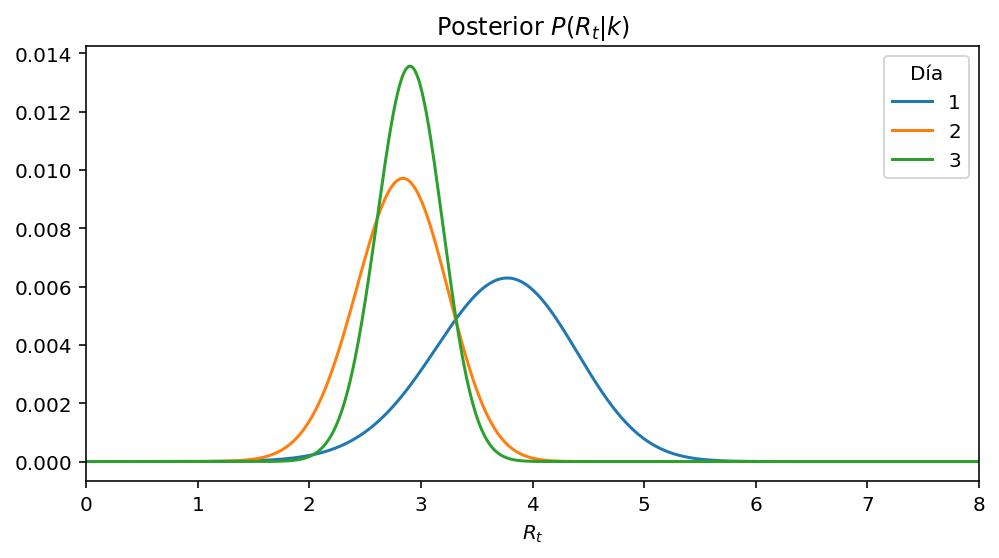

```python
posteriors = likelihood_r_t.cumprod(axis=1)
posteriors = posteriors / np.sum(posteriors, axis=0)

columns = pd.Index(range(1, posteriors.shape[1]+1), name='Día')
posteriors = pd.DataFrame(
    data = posteriors,
    index = r_t_range,
    columns = columns)

ax = posteriors.plot(
    title='Posterior $P(R_t|k)$',
    xlim=(0,8),
    figsize=(8,4)
)
ax.legend(title='Día')
ax.set_xlabel('$R_t$');
```

Es de notar que en el día 1, la probabilidad posterior es la misma que la del día 1 del gráfico anterior. Esto se debe a que no se tiene información previa a esa. Sin embargo, al actualizar con la información del día siguiente se aprecia el cambio, pero no tan marcado como en el anterior gráfico. Esto se debe a que se emplea la información de los dos días anteriores. Como la verosimilitud del día 3 esta entre las 2 previas solo se nota un pequeño desplazamiento. Lo que es más importante es que la distribución es más angosta, lo cual implica un incremento en la confianza sobre el valor de $R_t$.

Con estas probabilidades posteriores es posible responder para cada día preguntas importantes como: ¿Cuál es el valor más probable de $R_t$?

```python
most_likely_values = posteriors.idxmax(axis=0)
most_likely_values
```

```
Día
1    3.77
2    2.84
3    2.90
dtype: float64
```

Tambien se pueden obtener los intérvalos de densidad probabilística más alta para $R_t$, permitiendo de esta forma crear intervalos de confianza para los valores de $R_t$

```python
def highest_density_interval(pmf, p=.95, debug=False):
    # Para aplicarlo a un "DataFrame", simplemente es necesario llamar esta función recursivamente sobre las columnas
    if(isinstance(pmf, pd.DataFrame)):
        return pd.DataFrame([highest_density_interval(pmf[col], p=p) for col in pmf],
                            index=pmf.columns)

    cumsum = np.cumsum(pmf.values)

    # Matriz N x N de probabilidades para cada cota mínima y máxima del intervalo de confianza
    total_p = cumsum - cumsum[:, None]

    # Retorna todos los índices con total_p > p
    lows, highs = (total_p > p).nonzero()

    # Encontrando el rango más pequeño (máxima densidad)
    best = (highs - lows).argmin()

    low = pmf.index[lows[best]]
    high = pmf.index[highs[best]]

    return pd.Series([low, high],
                     index=[f'Low_{p*100:.0f}',
                            f'High_{p*100:.0f}'])

hdi = highest_density_interval(posteriors, debug=True)
hdi.tail()
```

| Día | Low_95 | High_95 |
| --- | --- | --- |
| 1 | 2.40 | 4.90 |
| 2 | 1.96 | 3.58 |
| 3 | 2.28 | 3.44 |

En este punto ya es posible graficar los valores más probables de $R_t$ y su intervalo de confianza al 95%. La gran utilidad de esta representación radica en que hace posible observar la evolución de las estimaciones realizadas a lo largo del tiempo.

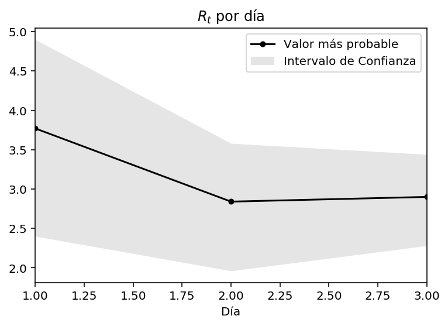

```python
ax = most_likely_values.plot(marker='o',
                             label='Valor más probable',
                             title=f'$R_t$ por día',
                             c='k',
                             markersize=4)

ax.fill_between(hdi.index,
                hdi['Low_95'],
                hdi['High_95'],
                color='k',
                alpha=.1,
                lw=0,
                label='Intervalo de Confianza')

ax.legend();
```

Se puede ver que el valor más probable de $R_t$ cambia en el tiempo y que el intérvalo de confianza se vuelve más estrecho al incrementar la certidumbre sobre el valor de $R_t$ con cada actualización diaria del número de casos. Como solo hay una historia de 4 días, no se aplicó todo el proceso para este ejemplo, ya que para empezar a observar resultados se requiere una historia más larga y un mayor número de casos.

## Aplicando el modelo a los datos de BOLIVIA

#### Setup

Se cargan los datos diarios de casos acumulados en Bolivia por departamento y totales nacionales

```python
# Los datos provienen del Sitio oficial del Gobierno de Bolivia sobre el Covid-19
# https://www.boliviasegura.gob.bo/estadisticas.php
# El autor ha hecho publico el archivo que recopila estos datos en
# https://www.kaggle.com/ashercroft/covid19-cases-in-bolivia-by-region

url = r'C:/carpeta_que_contiene_el_archivo/datos_covid.csv'
regions = pd.read_csv(url,
                     usecols=['date', 'region', 'cases'],
                     parse_dates=['date'],
                     index_col=['region', 'date'],
                     squeeze=True).sort_index()
```

Se visualizan los datos en escala logarítmica

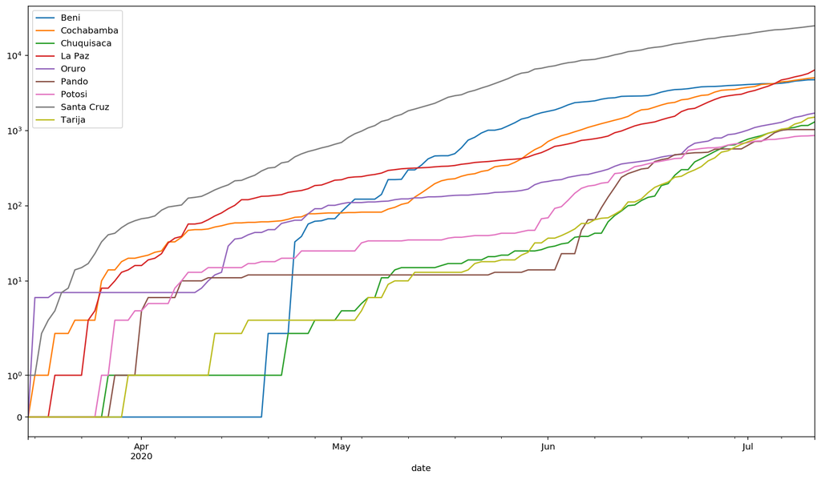

```python
#'BE', 'CB', 'CH', 'LP','OR', 'PD','PO','SC','TJ'
plt.figure(figsize=(16,9))

regions.xs('BE').rename(f"{'BE'} cases").plot(label='Beni')
regions.xs('CB').rename(f"{'CB'} cases").plot(label='Cochabamba')
regions.xs('CH').rename(f"{'CH'} cases").plot(label='Chuquisaca')
regions.xs('LP').rename(f"{'LP'} cases").plot(label='La Paz')
regions.xs('OR').rename(f"{'OR'} cases").plot(label='Oruro')
regions.xs('PD').rename(f"{'PD'} cases").plot(label='Pando')
regions.xs('PO').rename(f"{'PO'} cases").plot(label='Potosi')
regions.xs('SC').rename(f"{'SC'} cases").plot(label='Santa Cruz')
regions.xs('TJ').rename(f"{'TJ'} cases").plot(label='Tarija')

#casos_beni.plot(label = 'BENI')
#casos_oruro.plot(label = 'ORURO')
plt.legend()
plt.yscale('symlog' )
```

El reporte de casos en algunos departamentos parece ser muy errático, pueden haber multiples causas para que *el reporte* de casos se acumule en ciertos días mientras que los contagios se estén produciendo todo el tiempo.

Para reducir este efecto de acumulación de casos, preparamos los datos aplicando un filtro gausiano a la serie temporal. Hacer esto es una elección arbitraria, pero resulta razonable asumir que los contagios no se producen de una forma tan estocástica como muestra el reporte de los mismos.

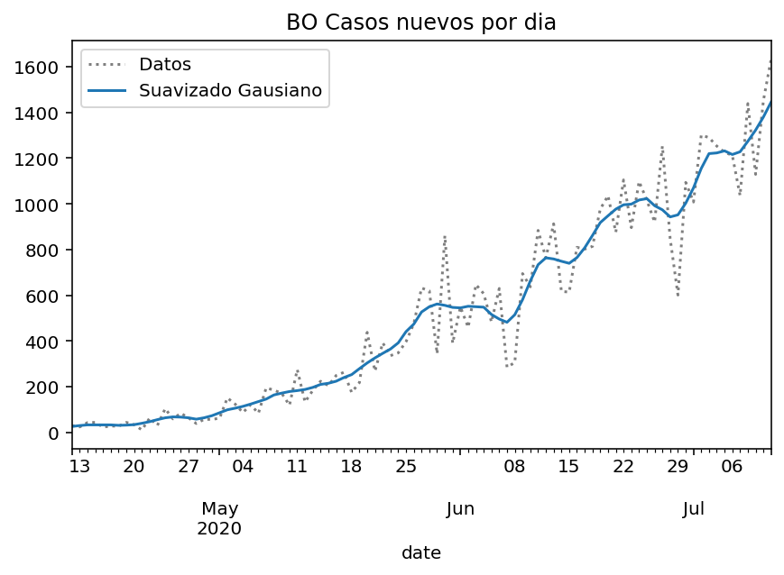

```python
region_name = 'BO'

def prepare_cases(cases, cutoff=25):
    new_cases = cases.diff()

    smoothed = new_cases.rolling(7,
        win_type='gaussian',
        min_periods=1,
        center=True).mean(std=2).round()

    idx_start = np.searchsorted(smoothed, cutoff)

    smoothed = smoothed.iloc[idx_start:]
    original = new_cases.loc[smoothed.index]

    return original, smoothed

cases = regions.xs(region_name).rename(f"{region_name} cases")

original, smoothed = prepare_cases(cases)

original.plot(title=f"{region_name} Casos nuevos por dia",
               c='k',
               linestyle=':',
               alpha=.5,
               label='Datos',
               legend=True,
             figsize=(500/72, 300/72))

ax = smoothed.plot(label='Suavizado Gausiano',
                   legend=True)

ax.get_figure().set_facecolor('w')
```

#### Elegiendo $\sigma$ para $P(R_t|R_{t-1})$

El enfoque original simplemente selecciona la probabilidad posterior de ayer como la probabilidad previa para hoy. Aunque es intuitivo, hacerlo de ese modo no da lugar a la conjetura de que el valor de $R_t$ posiblemente ha cambiado desde ayer. Para permitir ese cambio, se aplica ruido gausiano a la probabilidad previa con una desviación estandar $\sigma$. Para valores mayores de $\sigma$ se tiene un ruido de mayor amplitud y mayor será la espectativa de cambio de $R_t$. Es interesante mencionar que, al aplicar ruido sobre una señal ruidosa implica que habrá un decaimiento natural de probabilidades posteriores distantes. Este enfoque calcula una serie de valores de $R_t$ que explican todos los casos, asumiendo que $R_t$ fluctúa una cantidad $\sigma$ cada día.

Sin embargo, elegir un valor para $\sigma$ es arbitrario. Se propone usar una función de máxima verosimilitud para respaldar la selección de $\sigma$.

El proceso propuesto elije un $\sigma$ que maximiza la verosimilitud de ver el número de casos $k$: $P(k|\sigma)$. Como $\sigma$ es un valor constante, lo que se intenta hacer buscar el máximo $P(k)$ de entre todas las opciones de $\sigma$.

Como $P(k)=P(k_0,k_1,\ldots,k_t)=P(k_0)P(k_1)\ldots P(k_t)$ se necesita definir $P(k_t)$. Resulta que este es el denominador en la regla de Bayes:

$$P(R_t|k_t) = \frac{P(k_t|R_t)P(R_t)}{P(k_t)}$$

A fin de calcularlo, se identifica que el numerador es en realidad la distribución conjunta de $k$ and $R$:

$$ P(k_t,R_t) = P(k_t|R_t)P(R_t) $$

Se marginaliza la distribución sobre $R_t$ para obtener $P(k_t)$:

$$ P(k_t) = \sum_{R_{t}}{P(k_t|R_t)P(R_t)} $$

De esta forma, si se suma la distribución del numerador sobre todos los valores de $R_t$, se obtiene $P(k_t)$. Y como se esta calculando al mismo tiempo que la probabilidad posterior, se revisará por separado.

Como se esta buscando el valor de $\sigma$ que maximiza $P(k)$, en realidad se pretende maximizar lo siguiente:

$$\prod_{t,i}{p(k_{ti})}$$

donde $t$ representa todos los tiempos e $i$ representa cada departamento del país.

Como se estan multiplicando varias pequeñas probabilidades entre sí, resulta conveniente (y menos conducente a errores) el tomar el $\log$ de las probabilidades y sumar los resultados. Hay que recordar que $\log{ab}=\log{a}+\log{b}$. Y como los logaritmos solo incrementan de forma monótona, maximizar la suma de los $\log$ de las probabilidades es equivalente a maximizar el producto de las probabilidades no-logarítmicas para cualquier $\sigma$.

#### Función para calcular las probabilidades posteriores

Se siguen los siguientes pasos:

Calcular $\lambda$ - la tasa estimada de llegada para el proceso de Poisson de cada día Calcular la distribución de verosimilitud de cada día sobre todos los posibles valores de $R_t$ Calcular la matriz de proceso basada en el valor de $\sigma$ anteriormente descrito Calcular la probabilidad inicial, ya que se empieza sin una propabilidad previa al primer día De la información publicada por la **cdc** se ajusta el valor de Gamma a 4. Se itera desde el dia 1 hasta el dia final, con las siguientes instrucciones: Cacular la probabilidad previa mediante aplicar ruido gausiano a la probabilidad previa del dia anterior. Aplicar la regla de Bayes mediante multiplicar esta probabilidad previa por la verosimilitud que se calculó previamente. Dividir entre la probabilidad de los datos observados(aqui tambien se aplica la regla de Bayes)

```python
def get_posteriors(sr, sigma=0.15):

    # (1) Se calcula lambda
    lam = sr[:-1].values * np.exp(GAMMA * (r_t_range[:, None] - 1))


    # (2) Se calcula la verosimilitud para cada día
    likelihoods = pd.DataFrame(
        data = sps.poisson.pmf(sr[1:].values, lam),
        index = r_t_range,
        columns = sr.index[1:])

    # (3) Se crea la matriz gaussiana
    process_matrix = sps.norm(loc=r_t_range,
                              scale=sigma
                             ).pdf(r_t_range[:, None])

    # (3a) Se normaliza la suma de las columnas a 1
    process_matrix /= process_matrix.sum(axis=0)

    # (4) Se calcula la probabilidad inicial
    #prior0 = sps.gamma(a=4).pdf(r_t_range)
    prior0 = np.ones_like(r_t_range)/len(r_t_range)
    prior0 /= prior0.sum()

    # Se crea un"DataFrame" que guarda las prbabilidades posteriores para cada día
    # Se inserta el la primera probabilidad previa
    posteriors = pd.DataFrame(
        index=r_t_range,
        columns=sr.index,
        data={sr.index[0]: prior0}
    )

    # Se mecionó que se controlaría el valor de la suma de logaritmos
    # de la probabilidad de los datos para calcular la máxima verosimilitud.
    # Aqui se instancia su valor inicial

    log_likelihood = 0.0

    # (5) Se aplica la regla de Bayes iterativamente
    for previous_day, current_day in zip(sr.index[:-1], sr.index[1:]):

        #(5a) Calculando la "probabilidad previa" siguiente
        current_prior = process_matrix @ posteriors[previous_day]

        #(5b) Calculando el numerador de la regla de Bayes P(k|R_t)P(R_t)
        numerator = likelihoods[current_day] * current_prior

        #(5c) Calculando el denominador de la regla de Bayes P(k)
        denominator = np.sum(numerator)

        # Se aplica la regla de Bayes
        posteriors[current_day] = numerator/denominator

        # Se agrega a la suma de logaritmos de verosimilitudes
        log_likelihood += np.log(denominator)

    return posteriors, log_likelihood

# Notese que para el ejemplo usamos un valor de sigma elegido arbitrariamente
posteriors, log_likelihood = get_posteriors(smoothed, sigma=.15)
```

### El resultado

Abajo se pueden apreciar las distribuciónes posteriores de todos los días graficadas simultáneamente. Las primeras son bastante anchas ya que se tiene poca confiabilidad pero se vuelven cada vez más angostas ya que la confiabilidad de que incluyan el verdadero valor de $R_t$ incrementa.

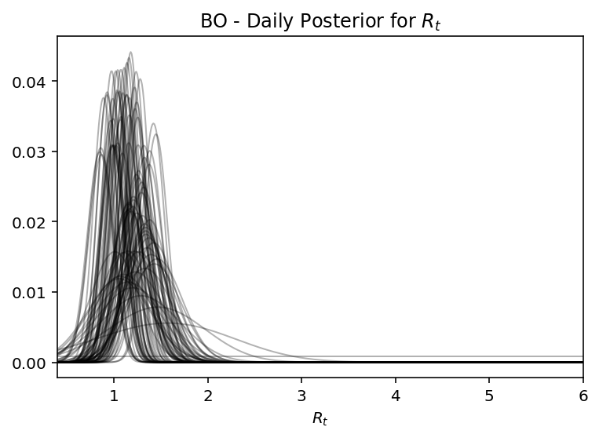

```python
ax = posteriors.plot(title=f'{region_name} - Daily Posterior for $R_t$',
           legend=False,
           lw=1,
           c='k',
           alpha=.3,
           xlim=(0.4,6))

ax.set_xlabel('$R_t$');
```

#### Graficando evolucion temporal con intervalos de confianza

Como los resultados deben incluir incertidumbre, resulta sumamente util poder visualizar los valores más probables junto con sus intervalos de mayor densidad.

```python
# El siguiente cálculo demora bastante
hdis = highest_density_interval(posteriors, p=.95)

most_likely = posteriors.idxmax().rename('ML')

result = pd.concat([most_likely, hdis], axis=1)

result.tail()
```

| date | ML | Low_95 | High_95 |
| --- | --- | --- | --- |
| 2020-07-07 | 1.02 | 0.82 | 1.20 |
| 2020-07-08 | 1.11 | 0.90 | 1.28 |
| 2020-07-09 | 1.14 | 0.94 | 1.31 |
| 2020-07-10 | 1.16 | 0.95 | 1.32 |
| 2020-07-11 | 1.18 | 0.98 | 1.34 |

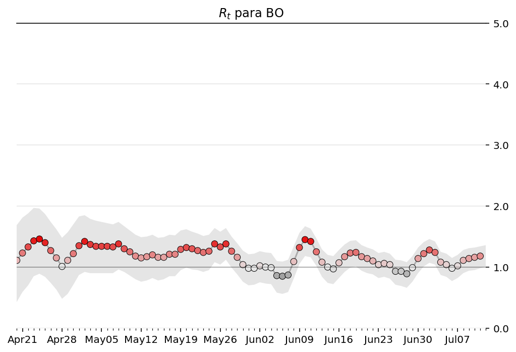

```python
def plot_rt(result, ax, region_name):

    ax.set_title(f"{region_name}")

    # Colores
    ABOVE = [1,0,0]
    MIDDLE = [1,1,1]
    BELOW = [0,0,0]
    cmap = ListedColormap(np.r_[
        np.linspace(BELOW,MIDDLE,25),
        np.linspace(MIDDLE,ABOVE,25)
    ])
    color_mapped = lambda y: np.clip(y, .5, 1.5)-.5

    index = result['ML'].index.get_level_values('date')
    values = result['ML'].values

    # Puntos y líneas
    ax.plot(index, values, c='k', zorder=1, alpha=.25)
    ax.scatter(index,
               values,
               s=40,
               lw=.5,
               c=cmap(color_mapped(values)),
               edgecolors='k', zorder=2)

    # Extrapolacion estética del intervalo de confianza (1 dia a cada lado)
    lowfn = interp1d(date2num(index),
                     result['Low_95'].values,
                     bounds_error=False,
                     fill_value='extrapolate')

    highfn = interp1d(date2num(index),
                      result['High_95'].values,
                      bounds_error=False,
                      fill_value='extrapolate')

    extended = pd.date_range(start=pd.Timestamp('2020-03-15'),
                             end=index[-1]+pd.Timedelta(days=1))

    ax.fill_between(extended,
                    lowfn(date2num(extended)),
                    highfn(date2num(extended)),
                    color='k',
                    alpha=.1,
                    lw=0,
                    zorder=3)

    ax.axhline(1.0, c='k', lw=1, label='$R_t=1.0$', alpha=.25);

    # Formato del gráfico
    ax.xaxis.set_major_locator(mdates.MonthLocator())
    ax.xaxis.set_major_formatter(mdates.DateFormatter('%b'))
    ax.xaxis.set_minor_locator(mdates.DayLocator())

    ax.yaxis.set_major_locator(ticker.MultipleLocator(1))
    ax.yaxis.set_major_formatter(ticker.StrMethodFormatter("{x:.1f}"))
    ax.yaxis.tick_right()
    ax.spines['left'].set_visible(False)
    ax.spines['bottom'].set_visible(False)
    ax.spines['right'].set_visible(False)
    ax.margins(0)
    ax.grid(which='major', axis='y', c='k', alpha=.1, zorder=-2)
    ax.margins(0)
    ax.set_ylim(0.0, 5.0)
    ax.set_xlim(pd.Timestamp('2020-04-20'), result.index.get_level_values('date')[-1]+pd.Timedelta(days=1))
    fig.set_facecolor('w')


fig, ax = plt.subplots(figsize=(600/72,400/72))


# Ejecutando la gráfica

plot_rt(result, ax, region_name)
ax.set_title(f'$R_t$ para {region_name}')
ax.xaxis.set_major_locator(mdates.WeekdayLocator())
ax.xaxis.set_major_formatter(mdates.DateFormatter('%b%d'))
```

Se realiza una regresión lineal para inspeccionar la pendiente y entender si los datos siguen alguna tendencia

```
La pendiente es-0.0271
```

[figure not shown]

```python
model = LinearRegression()
x = np.array(range( 1, len(result['ML']))).reshape(-1, 1)
y = result['ML']

model.fit(x,y[1:])
plt.plot(x,model.predict(x),c='k' ,lw=3)
plt.scatter(x,y[1:],c='r')
plt.ylim([0,4])

print ('La pendiente es' + str(round(model.coef_[0],4)))
```

#### Eligiendo el $\sigma$ óptimo

En la sección previa se mostró como obtener un valor de $\sigma$, pero en el cálculo anterior se asumió un valor. Ahora que es posible evaluar cada departamento con cualquier sigma, se tienen todas herramientas para encontrar el mejor $\sigma$.

Se mencionó previamente que se encontraría el valor de $\sigma$ que maximiza la verosimilitud de las distribuciones $P(k)$ de los datos. Para evitar hacer un "overfit" para un departamento en particular, se va a elegir el sigma que maximice $P(k)$ en el conjunto de todos los departamentos. Para hacerlo, se añaden todas los logaritmos de las verosimilitudes por departamento para cada valor de $\sigma$ y entre esos se elige al máximo.

```python
#regions.loc[('LP', pd.Timestamp('2020-07-07'))]
#regions.xs('LP').diff().tail()
#plt.plot(regions.xs('LP'))
```

```python
sigmas = np.linspace(1/20, 1, 20)

targets = regions.index.get_level_values('region')
regions_to_process = regions.loc[targets]#.drop('BO')

results = {}

for region_name, cases in regions_to_process.groupby(level='region'):

    print(region_name)
    new, smoothed = prepare_cases(cases, cutoff=25)

    if len(smoothed) == 0:
        new, smoothed = prepare_cases(cases, cutoff=10)

    result = {}

    # Guarda todas las probabilidades posteriores con cada valor dado de sigma
    result['posteriors'] = []

    # Guarda los logaritmos de las verosimilitudes para todos los $k$  para cada valor de sigma
    result['log_likelihoods'] = []

    for sigma in sigmas:
        posteriors, log_likelihood = get_posteriors(smoothed, sigma=sigma)
        result['posteriors'].append(posteriors)
        result['log_likelihoods'].append(log_likelihood)

    # Guarda todos los resultados
    results[region_name] = result
    clear_output(wait=True)

print('Finalizado.')
```

```
Finalizado.
```

Ahora que se tienen todos las verosimilitudes logarítmicas, es posible sumar todos los valores de sigma y graficarlos y elegir el máximo

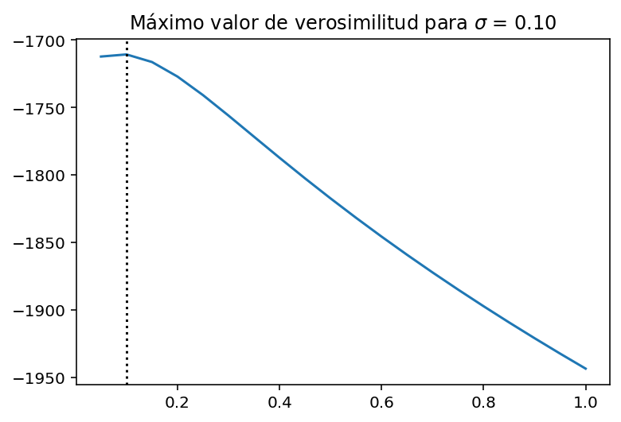

```python
# Cada índice de este "array" contiene el total de las verosimilitudes logaritmicass para
# el correspondiente indice del array de sigmas.
total_log_likelihoods = np.zeros_like(sigmas)

# Se iteran los resultados de cada region y se añaden las versimilitudes logarítmicas al total.
for region_name, result in results.items():
    total_log_likelihoods += result['log_likelihoods']

# Se selecciona el índice con la verosimilitud logarítmica total más larga
max_likelihood_index = total_log_likelihoods.argmax()

# Se selecciona el valor que tiene la más alta verosimilitud logarítmica
sigma = sigmas[max_likelihood_index]

# Se hace el gráfico
fig, ax = plt.subplots()
ax.set_title(f"Máximo valor de verosimilitud para $\sigma$ = {sigma:.2f}");
ax.plot(sigmas, total_log_likelihoods)
ax.axvline(sigma, color='k', linestyle=":")
```

## Compilando Resultados

Dado que se han seleccionado los $\sigma$'s óptimos, se toma el posterior precalculado correspondiente a ese valor de $\sigma$ para cada departamento. Adicionalmente se calculan dos intervalos de densidad más alta (95% y 50%) y tambien el valor más probable.

```python
# Esto puede demorar

final_results = None

for region_name, result in results.items():
    print(region_name)
    posteriors = result['posteriors'][max_likelihood_index]
    hdis_95 = highest_density_interval(posteriors, p=.95)
    hdis_50 = highest_density_interval(posteriors, p=.5)
    most_likely = posteriors.idxmax().rename('ML')
    result = pd.concat([most_likely, hdis_95, hdis_50], axis=1)
    if final_results is None:
        final_results = result
    else:
        final_results = pd.concat([final_results, result])
    clear_output(wait=True)

print('Finalizado.')
```

```
Finalizado.
```

### Graficando $R_t$ para cada departamento

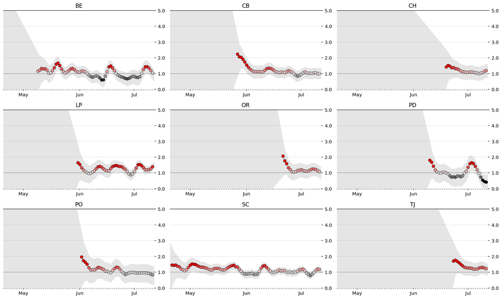

```python
ncols = 3
nrows = 3

fig, axes = plt.subplots(nrows=nrows, ncols=ncols, figsize=(15, nrows*3))
plt.title('Evolución del Número de Reproducción del COVID-19 por Departamento entre Abril y Julio 8')

for i, (region_name, result) in enumerate(final_results.drop('BO').groupby('region')):
    plot_rt(result.iloc[1:], axes.flat[i], region_name)


fig.tight_layout()

fig.set_facecolor('w')
```

```python
# Como se empezó a usar una probabilidad previa uniforme, ya no hace falta el primer dato de la serie
# asi que lo truncamos
final_results = final_results.groupby('region').apply(lambda x: x.iloc[1:].droplevel(0))
```

#### Estimaciones por Departamento a la fecha

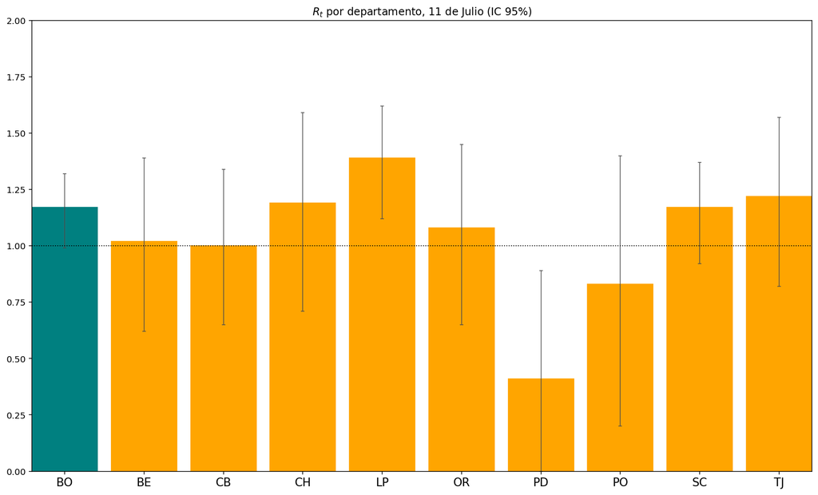

```python
nacional = [
    'Bolivia', 'BO',
]
departamental = [
    'La Paz', 'LP',
    'Cochabamba', 'CB',
    'Santa Cruz', 'SC',
    'Beni', 'BE',
    'Pando', 'PD',
    'Oruro', 'OR',
    'Potosi', 'PO',
    'Chuquisaca', 'CH',
    'Tarija', 'TJ'
]


FULL_COLOR = [.7,.7,.7]
NONE_COLOR = 'teal'
PARTIAL_COLOR = 'orange'
ERROR_BAR_COLOR = [.3,.3,.3]

mr = final_results.groupby(level=0)[['ML', 'High_95', 'Low_95']].last()

def plot_standings(mr, figsize=None, title='$R_t$ por departamento, 11 de Julio (IC 95%)'):
    if not figsize:
        figsize = ((15.9/10)*len(mr)+.1,9.5)

    fig, ax = plt.subplots(figsize=figsize)

    ax.set_title(title)
    err = mr[['Low_95', 'High_95']].sub(mr['ML'], axis=0).abs()
    bars = ax.bar(mr.index,
                  mr['ML'],
                  width=.825,
                  color=FULL_COLOR,
                  ecolor=ERROR_BAR_COLOR,
                  capsize=2,
                  error_kw={'alpha':.8, 'lw':1},
                  yerr=err.values.T)

    for bar, region_name in zip(bars, mr.index):
        if region_name in nacional:
            bar.set_color(NONE_COLOR)
        if region_name in departamental:
            bar.set_color(PARTIAL_COLOR)

    labels = mr.index.to_series()
    ax.set_xticklabels(labels, rotation=0, fontsize=13)
    ax.margins(0)
    ax.set_ylim(0,2.)
    ax.axhline(1.0, linestyle=':', color='k', lw=1)

    #leg = ax.legend(handles=[
    #                    Patch(label='Full', color=FULL_COLOR),
    #                    Patch(label='Partial', color=PARTIAL_COLOR),
    #                    Patch(label='None', color=NONE_COLOR)
    #                ],
    #                title='Lockdown',
    #                ncol=3,
    #                loc='upper left',
    #                columnspacing=.75,
    #                handletextpad=.5,
    #                handlelength=1)

    #leg._legend_box.align = "left"
    fig.set_facecolor('w')
    return fig, ax

#mr.sort_values(['High_95'], inplace=True)
plot_standings(mr.reindex(['BO','BE', 'CB', 'CH', 'LP','OR', 'PD','PO','SC','TJ']));
```

## Proyecciones usando el modelo SIR

Se instancian las constantes con relevancia para el modelo SIR

```python
# Población de Bolivia
# tomada de https://www.ine.gob.bo/subtemas_cuadros/demografia_html/PC20106.htm
N = 11633371
# Número de infectados y recuperados a la fecha, I0 y R0.
I0, R0 = 31113, 16087
# Población suceptible
S0 = N - I0 - R0
# Tasa de contacto, beta= R_0 * gamma, y tasa media de recuperación, gamma, (en 1/días).
gamma2 = 1./14
#beta = R_0 * gamma2
```

Se toman los valores más recientes de $R_t$

```python
#R_h95 = stats.mean(final_results.loc['BO'].iloc[:-1]['High_95'])
#R_l95 = stats.mean(final_results.loc['BO'].iloc[:-1]['Low_95'])
#R_h50 = stats.mean(final_results.loc['BO'].iloc[:-1]['High_50'])
#R_l50 = stats.mean(final_results.loc['BO'].iloc[:-1]['Low_50'])
#R_ml = stats.mean(final_results.loc['BO'].iloc[:-1]['ML'])
R_h95 = final_results.loc['BO'].iloc[-1]['High_95']
R_l95 = final_results.loc['BO'].iloc[-1]['Low_95']
R_h50 = final_results.loc['BO'].iloc[-1]['High_50']
R_l50 = final_results.loc['BO'].iloc[-1]['Low_50']
R_ml = final_results.loc['BO'].iloc[-1]['ML']
# Comentar fuente
R_minsalud = 2.7
```

```python
# Número de días a considerar
t = np.linspace(0, 300, 301)
```

### Ecuaciones diferenciales del modelo SIR

```python
def SIR_model(y, t, N, beta, gamma2):
    S, I, R = y
    dSdt = -beta * S * I / N
    dIdt = beta * S * I / N - gamma2 * I
    dRdt = gamma2 * I
    return dSdt, dIdt, dRdt

# Vector de condiciones iniciales
y0 = S0, I0, R0
```

Se realiza la integración del modelo **SIR** sobre el número de dias considerado para los siguientes parámetros:

```python
# Proyección del R_minsalud
ret = odeint(SIR_model, y0, t, args=(N, R_minsalud * gamma2, gamma2))
S, I_minsalud, R = ret.T

# Intervalo High 95
ret = odeint(SIR_model, y0, t, args=(N, R_h95 * gamma2, gamma2))
S, I_h95, R = ret.T

# Intervalo High 50
ret = odeint(SIR_model, y0, t, args=(N, R_h50 * gamma2, gamma2))
S, I_h50, R = ret.T

# Intervalo Low 50
ret = odeint(SIR_model, y0, t, args=(N, R_l50 * gamma2, gamma2))
S, I_l50, R = ret.T

# Intervalo Low 95
ret = odeint(SIR_model, y0, t, args=(N, R_l95 * gamma2, gamma2))
S, I_l95, R = ret.T

# Más probable
ret = odeint(SIR_model, y0, t, args=(N, R_ml * gamma2, gamma2))
S, I_ml, R = ret.T
```

Se revisan algunos valores obtenidos de los modelos para el caso más probable

```python
# Maximo numero de enfermos simultaneos
int(max(I_ml))
```

```
153558
```

```python
# Número total de casos
int(max(R))
```

```
510944
```

```python
# Porcentaje de la poblacion que se enferma
100*max(R)/N
```

```
4.392056557307733
```

```python
# Porcentaje de la población que no se enferma
100*min(S)/N
```

```
95.48720728121305
```

```python
# Numero de dias hasta el pico:
for j in range(len(I_ml)):
    if I_ml[j] == max(I_ml):
        print(j)
```

```
222
```

Se da formato de series temporales a los vectores obtenidos del modelo SIR

```python
proy_h95 = pd.Series(I_h95)
proy_h95.index = pd.to_datetime(proy_h95.index, unit = 'D' , origin = '2020-07-07' )
#proy_h95
```

```python
proy_h50 = pd.Series(I_h50)
proy_h50.index = pd.to_datetime(proy_h50.index, unit = 'D' , origin = '2020-07-07' )
#proy_h95
```

```python
proy_l50 = pd.Series(I_l50)
proy_l50.index = pd.to_datetime(proy_l50.index, unit = 'D' , origin = '2020-07-07' )
#proy_h95
```

```python
proy_l95 = pd.Series(I_l95)
proy_l95.index = pd.to_datetime(proy_l95.index, unit = 'D' , origin = '2020-07-07' )
#proy_l95
```

```python
proy_ml = pd.Series(I_ml)
proy_ml.index = pd.to_datetime(proy_ml.index, unit = 'D' , origin = '2020-07-07' )
#proy_ml
```

```python
proy_minsalud = pd.Series(I_minsalud)
proy_minsalud.index = pd.to_datetime(proy_minsalud.index, unit = 'D' , origin = '2020-07-07' )
#proy_l95
```

### Visualizando los resultados del modelo SIR

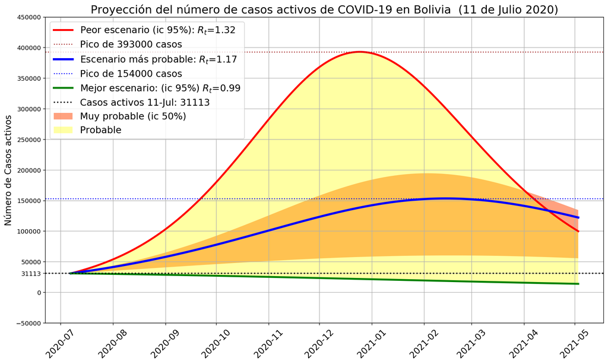

```python
fig= plt.figure(figsize=(16,9))
plt.rcParams.update({'font.size': 15})

#plt.title('Proyecciones gubernamentales de número de Casos de COVID-19 en Bolivia ( al 8 de Julio)',fontsize=18 )
plt.title('Proyección del número de casos activos de COVID-19 en Bolivia  (11 de Julio 2020)' , fontsize=18 )
#plt.plot(proy_minsalud, label='Proyección Min. Salud', color = 'r' )
#plt.axhline( max(proy_minsalud), linestyle=':', color='r', lw=1.5, label = str(int(max(proy_minsalud)))+' casos')

plt.plot(proy_h95,  label='Peor escenario (ic 95%): $R_t$='+ str(round(R_h95,2)), color = 'red',  lw=3.0)
plt.axhline(max(proy_h95),  linestyle=':',  color='brown', lw=1.5, label = 'Pico de '+ str(int(round(max(proy_h95),-3))) +' casos')

#plt.plot(proy_h50,  label='Realista (ic 50%): $R_t$='+ str(round(R_h50,2)), color = 'k',  lw=0.5)
#plt.axhline(max(proy_h95),  linestyle=':',  color='k', lw=1.5, label = 'Pico '+ str(int(max(proy_h95))) +' casos')

plt.plot(proy_ml, label='Escenario más probable: $R_t$='+ str(round(R_ml,2)), color='b', lw=3.5)
plt.axhline(max(proy_ml), linestyle=':', color='b', lw=1.5, label ='Pico de '+ str(int(round(max(proy_ml),-3))) +' casos')

#plt.plot(proy_l50,  label='Realista (ic 50%): $R_t$='+ str(round(R_l50,2)), color = 'k',  lw=0.5)
#plt.axhline(max(proy_h95),  linestyle=':',  color='k', lw=1.5, label = 'Pico '+ str(int(max(proy_h95))) +' casos')

plt.plot(proy_l95, label='Mejor escenario: (ic 95%) $R_t$=' + str(round(R_l95,2)), color='green', lw=3.0)
#plt.axhline( 130000, linestyle='dashed', color='k', lw=1.5, label = 'Proyección UDAPE: '+ str(130000) +' casos')

plt.axhline(I0, linestyle=':', color='k', label = 'Casos activos 11-Jul: '+ str(int(I0)), lw=2  )

plt.fill_between(proy_l95.index,proy_h50, proy_l50, facecolor='orangered',alpha=0.5, label= 'Muy probable (ic 50%)')
plt.fill_between(proy_l95.index,proy_h95, proy_l95, facecolor='yellow', alpha=0.36,label= 'Probable')



plt.rc('xtick', labelsize=14)
plt.rc('ytick', labelsize=10)



plt.yticks(list(plt.yticks()[0])+ [int(I0)])


plt.xticks ( rotation=45 )
#plt.yticks (100,1000,10000,100000,1000000)
plt.ylabel('Número de Casos activos',fontsize=14)
plt.grid(True, axis = 'both')
#plt.axhline(y=max(I), color='k', linestyle= 'dotted', label= max(I))
plt.legend()
#plt.yscale('symlog', )

plt.show()
```

Se puede observar que el pico de casos activos se producirá un día entre el 11 de Julio y el mes de Febrero de 2021, esto se reporta con intervalo de confiabilidad del 95%. Evidentemente este resultado es trivial, dado que comprende un intervalo de varios meses, pero reportarlo de otra manera sería deshonesto. El escenario más probable es solo una guía y no debería considerarse como el valor representantivo del reporte en este tipo de proyección. El peor escenario es el que resulta más util para establecer una respuesta estratégica ante la pandemia. El caso nacional esta lejos de ser la aplicación óptima de este modelo. Más adelante se exponen los motivos para evitar este tipo de aplicación del modelo y se sugieren algunos escenarios ideales.

Si redujéramos el intervalo del reporte reduciríamos la confiabilidad con la que estamos reportanto lo cual equivaldría a "apostar", si se quiere, con las espectativas del lector. Un intervalo de confiabilidad de 95% esta muy extendido en la ciencia ya que no se desea asumir un riesgo mayor al 5% de que el reporte sea erróneo, *sobre todo cuando se trata de un tema de salud*.

## DISCUSION

### Acerca de la estimación de $R_t$

El enfoque Bayesiano de estimación de $R_t$ permite hacer uso de los datos disponibles para monitorear la evolución de este parámetro. El registro de sus sucesivos valores en el tiempo muestra variaciones que pueden ser identificadas como variaciones en la tasa de contagios o en la tasa de pruebas administradas, registros históricos de actividades de rastrillaje, eventos masivos o variaciones en las regulaciones de circulación pueden ser usados para identificar el origen de las variciones de $R_t$. Es sumamente importante hacer notar que existe un lapso de tiempo entre el momento en que se produce el contagio y el momento en que se registra como caso positivo, por tanto debe existir un retraso entre las actividades que puedan modificar $R_t$ y el registro de la modificación de su valor. Este retraso tendrá como pricipales componentes: el intervalo entre el contagio, la aparición de síntomas y la atención médica, además del tiempo de procesamiento del la prueba, en casos rurales se especula que estos tiempos pueden ser significativamente mayores debido a la necesidad del traslado del paciente o de la muestra. Por otro lado, los datos disponibles no especifican el tipo de prueba utilizada para la confirmación del caso, dada la administración de pruebas rápidas de COVID-19 se debe advertir que el retraso de las variaciones de $R_t$ puede verse afectado, esto implica la pérdida de resolución temporal. Sin embargo, las tendencias a plazos más largos que la diferencia entre pruebas rápidas y pruebas regulares se mantienen inalteradas, en otras palabras, puede que los picos sean menos pronunciados o más extendidos en el tiempo.

Es importante mencionar que en el caso de Bolivia la cantidad de pruebas por habitante es todavía baja comparada con otros países, esto añade incerteza a los datos manejados. Dado que uno de los principales intereses en el monitoreo de $R_t$ es el de evaluar los efectos de cambios en restricciones sociales (circulación, distanciamiento social y otros), y que a pesar de la mayor incertidumbre, las tendencias inducidas por estas restricciones son capaces de reflejarse proporcionalmente en los casos que se registran , no se puede descartar $R_t$ en base a una incertidumbre respecto al número de casos totales o a la proporción de casos registrados. Objeciones a este último argumento podrían ser que de alguna forma las restricciones no se apliquen equitativamente a toda la población, o que de alguna forma las pruebas se administren sistemáticamente a cierta parte de la población y no a otra. A la fecha, no se conoce de evidencia de que alguna de esas cosas ocurra en Bolivia.

Ya que diferentes regiones y ciudades tienen diferentes formas de implementar las restricciones, además de diferentes variables ambientales, es necesario recomendar la estimación de R a la escala más pequeña posible. Idealmente a nivel de ciudades o incluso barrios, si es que existen suficientes casos. A escala nacional su uso es contraproducente ya que cada región es un caso diferente, sobre todo por que las políticas de escala nacional tienen a requerir plazos más largos en su gestión e implementación, esto implica que se requieran proyecciones a plazos más largos que son, por tanto, menos confiables.

### Acerca de la proyección usando el modelo SIR

Se justifica el uso del modelo SIR para la proyección del número de casos activos bajo los siguientes argumentos:

- El modelo SIR es simple: sus parámetros son posibles de medir y su interpretación esta al alcance de los profesionales de la salud, de los encargados de la administración publica y es puede hacerse accesible a la población en general. Esto lo diferencia de prometedores modelos como el de Tsallis [7], que registra excelentes concordancias con los datos para ciertos paises pero para extender esos resultados a algunos países es necesario hacer excepciones y cambiar parámetros que se suponía que pertenecen a la biología de la enfermedad, lo cual remarca que no hay certeza plena en la interpretción de sus parámetros y por tanto el poder predictivo de sus resultados es cuestionable. El ajuste de Tsallis implica una gran esperanza para el futuro, pero en su estado actual, mientras todavía no sabemos si Bolivia es parte de la norma o de las excepciones en sus predicciones, no es recomendable basar la seguridad sanitaria de la población en el mismo.
- Existen numerosas fuentes de referencia, y mucha teoría epidemiológica desarrollada alrededor del modelo SIR, haciendo que la progresión hacia modelos similares pero más intricados sea natural y relativamente libre de grandes complicaciones.
- Modelos derivados no se especializan tanto en enfermedades emergentes como el modelo SIR. Ya que la gran mayoría de la población todavía es suceptible (más del 99% a la fecha), el modelo SIR y sus derivados arrojan resultados muy similares.

#### Limitaciones del modelo SIR

El modelo SIR asume que todo individuo es capaz de interactuar con todo otro individuo de la población. Tambien asume que la población es constante (no toma en cuenta cambios en la población resultado de nacimientos, fallecimientos o migración). También asume que los recuperados no vuelven a infectarse. No toma en cuenta variaciones la tasa de recuperación relacionadas con características como edad o sexo. Por último, tampoco toma en cuenta la variación de los parámetros biológicos de virus (mutaciones) que podrían modificar su transmisibilidad o la progresión temporal de la enfermedad en el infectado.

Como los intervalos de tiempo que se pretenden modelar son meses, la variación de la población que se puede esperar debida a nacimientos y fallecimientos es pequeña y es razonable no tomarla en cuenta en el modelo. La migracion esta fuertemente restringida asi que tambien se puede despreciar. No se han reportado casos de recuperados que vuelvan a infectarse y esparcir la enfermedad, si bien no se conoce si la inmunidad es permanente, el tiempo de inmunidad parece ser lo suficientemente largo como para que no se necesite modificar el modelo si es aplicado en el intervalo de meses, tal y como se pretende. Se afronta el problema de las diferencias en las tasas de recuperación entre diferentes grupos etarios de la poblacion mediante usar un valor promedio de toda la población, ya que se trata de una cantidad grande de casos esta estimación es razonble. En cuanto a las mutaciones del virus, se puede esperar que el virus cambie en la escala de años o meses, si se realizan proyecciones a días o semanas es razonable esperar que los parámetros biológicos del virus no hayan cambiado apreciablemente. Esto último subraya la importancia evitar las proyecciones de largo y mediano plazo.

La última consideración respecto a limitaciones del modelo SIR se refiere la posibilidad de un individuo de interactuar con todos los otros individuos de la población. Dadas las restricciones vigentes a viajes es posible decir que cada ciudad esta aislada de las otras, esto hace que el modelo SIR no sea estrictamente válido para el caso nacional, o para los casos departamentales. Esta última consideración no es válida solo para este modelo, sino que es válida para todo otro modelo que no considere que la población esta acumulada en compartimentos geográficos. La solución ideal a esto es aplicar el modelo SIR a cada localidad, determinando también el $R_t$ local.

#### Otras consideraciones

La propagación del virus también depende de factores sociales, que solo pueden ser tomados en cuenta invocando múltiples variables, esto añade considerablemente a la complejidad de cualquier modelo que intente describirlo. Tambien se puede argumentar que la percepción social sobre la seriedad de la propagación afecta la propia propagación, ese es un indicador de la no-linealidad de fenómeno observado. Fenómenos no lineales, por ejemplo el clima, no suelen pronosticarse a largo o incluso mediano plazo.

## CONCLUSIONES

Debido a que $R_t$ depende de factores biológicos, sociales y ambientales que son distintos en cada núcleo poblacional. Se debería estimar el valor de $R_t$ para cada núcleo poblacional que tenga suficientes casos para realizar la estimación.

A raíz de los posibles cambios poblacionales por nacimientos y fallecimientos, la incertidumbre acerca de la permanencia en el estado inmune y la posibilidad de mutación del virus, no es recomentable hacer proyecciones a largo plazo.

Debido a las restriciones a los viajes entre ciudades, es recomendable que el modelo SIR se aplique solo a núcleos poblacionales donde el desplazamiento se pueda considerar *libre* bajo el marco de las restricciones sanitarias.

La naturaleza social de la propagación del virus limita seriamente la posibilidad de hacer pronósticos extendidos sobre número de casos.

#### Consideraciones finales

Se ha mostrado que es posible hacer una proyección del pico de casos a nivel nacional con las herramientas expuestas en este 'notebook', pero solo se pretende su análisis a nivel ilustrativo para ser reproducido a escala de núcleos urbanos. Se han expuesto las consideraciones y limitaciones de los métodos y modelos usados y se ha discutido sobre los escenarios más óptimos para su aplicación. Tomando como referencia el clima, y el hecho de que el clima tambien influye en la dispersión de la enfermedad, es razonable descartar la validez de cualquier predicción a más de 2 o 3 semanas.

Dada la seriedad de la situación, se hace necesario señalar algunos casos ideales de aplicación de estos métodos y modelos:

- Es ideal usar la estimación de $R_t$ para evaluar si un cambio reciente de la cuarentena, ya sea quitar o aumentar restricciones, esta teniendo el efecto suficiente mientras se mantiene la progresión de casos bajo control.
- Es ideal usar el modelo SRI en conjuncion con la estimación local de $R_t$ para determinar cuanto tiempo se tiene hasta que el numero de casos rebase la capacidad hospitalaria local

### Reconocimiento

Se reconoce que el autor no posee credenciales de medicina o epidemiología, en cambio si posee credenciales de ciencias físicas y, por consiguiente, de estadística y modelos matemáticos.

### Agradecimiento

Se agradece un profusamente a Kevin Systrom, quien inspiró la producción de este notebook con sus artículos al inicio de la pandemia y que contribuyó en gran medida al mismo al publicar parte de su código.

### REFERENCIAS

[1] Bettencourt LMA, Ribeiro RM (2008) Real Time Bayesian Estimation of the Epidemic Potential of Emerging Infectious Diseases. PLoS ONE 3(5): e2185. https://doi.org/10.1371/journal.pone.0002185

[2] Systrom K., The Metric We Need to Manage COVID-19 Rt: the effective reproduction number (April 12, 2020)

[3] W.O. Kermack and A.G. McKendrick, A contribution to the mathematical theory of epidemics, Proc. R. Soc. Lond, 115(1927), 700-721.

[4] Ying Liu, Albert A Gayle, Annelies Wilder-Smith, Joacim Rocklöv, The reproductive number of COVID-19 is higher compared to SARS coronavirus, Journal of Travel Medicine, Volume 27, Issue 2, March 2020, taaa021, https://doi.org/10.1093/jtm/taaa021

[5] Du, Z., Xu, X., Wu, Y., Wang, L., Cowling, B. J., & Meyers, L. (2020). Serial Interval of COVID-19 among Publicly Reported Confirmed Cases. Emerging Infectious Diseases, 26(6), 1341-1343. https://dx.doi.org/10.3201/eid2606.200357.

[6] Margaretha Annelie Vink, Martinus Christoffel Jozef Bootsma, Jacco Wallinga. Serial Intervals of Respiratory Infectious Diseases: A Systematic Review and Analysis. American Journal of Epidemiology, Volume 180, Issue 9, 1 November 2014, Pages 865–875, https://doi.org/10.1093/aje/kwu209

[7] Constantino Tsallis, Ugur Tirnakli. Predicting COVID-19 Peaks Around the World. Frontiers in Physics, 2020; 8 DOI: 10.3389/fphy.2020.00217

[8]Tommaso Alberti and Davide Faranda. On the uncertainty of real-time predictions of epidemic growths: A COVID-19 case study for China and Italy. Commun Nonlinear Sci Numer Simul. 2020 Nov; 90: 105372, Published online 2020 Jun 1. doi:10.1016/j.cnsns.2020.105372

[9] Benjamin Ridenhour, Jessica M. Kowalik, and David K. Shay. El número reproductivo básico (R0): consideraciones para su aplicación en la salud pública. Am J Public Health. 2018 December; 108(Suppl 6): S455–S465. Published online 2018 December. Spanish. doi:10.2105/AJPH.2013.301704s

[10] Delamater PL, Street EJ, Leslie TF, Yang Y, Jacobsen KH. Complexity of the Basic Reproduction Number (R0). Emerg Infect Dis. 2019;25(1):1-4. https://dx.doi.org/10.3201/eid2501.171901

[11] Fraser C., Donnelly C.A., Cauchemez S. et al. (2009). Pandemic Potential of a Strain of Influenza A (H1N1): Early Findings. Science 19 Jun 2009: Vol. 324, Issue 5934, pp. 1557-1561 DOI:10.1126/science.1176062